```python
import numpy as np
import matplotlib
import matplotlib.pyplot as plt
from IPython.display import display, Math, HTML, Javascript
import pandas as pd
```

# Introduction

In this notebook I will go through how I have set up the styling and extensions for my Jupyter Notebooks. It should generally improve readability and quality-of-life for the Notebook user. The notebooks will describe the contents of the following files:

If you are using Anaconda, the paths may be different. Below I will go through each of these files.

Together these file form my customization of my Jupyter notebooks.

# Notebook Extensions

I use the following extensions

1. **ExecuteTime** -- This puts the runtime as well as a timestamp at the end of every cell that has been executed.
2. **autoreload** -- Allows me to have some module automatically reload. Handy when you can to keep some of your function outside the notebook, but still have the convenience of quick editing.
3. **Hinterland** -- Enable code autocompletion menu for every keypress in a code cell, instead of only enabling it with tab.
4. **Highlight selected word** -- As the name suggests it highlights all occurrences of the selected word.
5. **Table of content** -- This allows me include a table of content in the notebook.

# Custom CSS for the notebook

I love Jupyter Notebook, but there are some things about the default styling of the cells that I don't like, e.g. the figures are left-centered and the text fields are too wide. So I was quite happy to learn that Jupyter will use the following file if it exists: `~/.jupyter/custom/custom.css`.

```
@import url("https://fonts.googleapis.com/css?family=Muli");

body {
  font-family: "Muli", sans-serif;
}

img {
  display: block;
  margin: auto;
}
```

# Defining a reference figure

Since we will be comparing the styling and position of figures I will define a function that returns a figure.

```python
n_curves = 4
random_data = np.random.rand(100,n_curves)
sorted_data = [sorted(random_data[:,i]) for i in range(n_curves)]
def create_figure(sorted_data, fig_name):
    fig, ax = plt.subplots()
    for y in sorted_data:
        ax.plot(y, label='label');
    ax.set_title("Title", loc='left')
    ax.set_xlabel('X Label')
    ax.set_ylabel('Y Label')
    ax.legend()
    fig.tight_layout()
    fig.savefig('../figs/'+fig_name)
    return fig
```

Lets have a look at the plain figure.

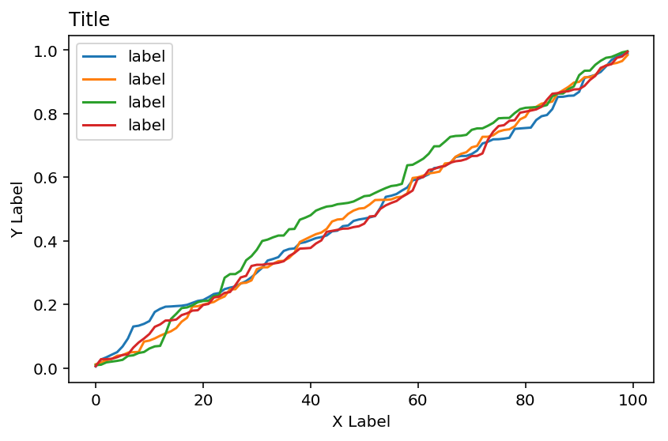

```python
fig = create_figure(sorted_data, 'plain')
```

# Figure in the margin

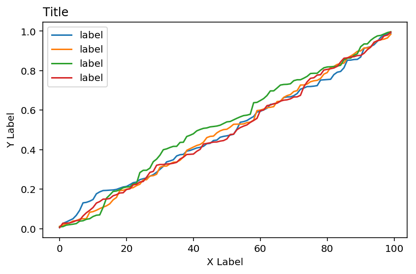

```python
fig = create_figure(sorted_data, 'plain')
Javascript('this.element.attr("id", "margin-figure")')
```

Sometimes it would be nice ot break the linear flow of the document by including figures in the margin. To achieve this we will need to add a css ID to the output cell so we can reference it and give it specific styling.

# Table in the margin

There is nothing about the code above that is speficic to figures. So we can do the same thing with tables.

```python
display(HTML(pd.DataFrame(np.random.rand(5,4)).to_html()))
Javascript('this.element.attr("id", "margin-figure")')
```

|  | 0 | 1 | 2 | 3 |
| --- | --- | --- | --- | --- |
| 0 | 0.901957 | 0.814118 | 0.304787 | 0.184515 |
| 1 | 0.135993 | 0.106022 | 0.914976 | 0.000161 |
| 2 | 0.468062 | 0.923770 | 0.869499 | 0.204292 |
| 3 | 0.684688 | 0.461955 | 0.365184 | 0.302672 |
| 4 | 0.570566 | 0.361042 | 0.399439 | 0.343895 |

# Creating high quality inline figures

One can change the default setting for iPython. Running `ipython profile create` one can creates the file `~/.ipython/profile_default/ipython_config.py` that contains all the configs, see [this](https://gist.github.com/minrk/3301035). By adding `c.InlineBackend.figure_format = 'retina'` to the file, the resolution of the inline figures is improved greatly. This also means that the figures will have the same resolution if you save them by dragging.

# Styling Matplotlib figures

Below I define a function that creates a figure and returns the figure object so I can save the figure. I want to be able to compare the figures as I change the styling.

First I create the plain figure using the default styling that comes with MatplotLib.

```python
fig = create_figure(sorted_data, 'plain')
```

[output not shown]

We want out figures to have a print quality, so we will set the figure format to retina. This should make the figure look a lot sharper.

We can alter the default parameters used by matplotlib by changing the values in the `plt.rcParams` dictionary.

Below I will change some of the styling:

```python
# %load matplotlib_config.py
plt.rcParams['savefig.dpi'] = 200
plt.rcParams['figure.autolayout'] = False
plt.rcParams['figure.figsize'] = 7, 4
plt.rcParams['axes.labelsize'] = 12
plt.rcParams['axes.titlesize'] = 14
plt.rcParams['xtick.labelsize'] = 12
plt.rcParams['ytick.labelsize'] = 12
plt.rcParams['font.size'] = 16
plt.rcParams['lines.linewidth'] = 2.0
plt.rcParams['lines.markersize'] = 8
plt.rcParams['legend.fontsize'] = 14
plt.rcParams['text.usetex'] = False
```

Lets plot the figure again now that the defaults have ben changed.

```python
fig = create_figure(sorted_data, 'new_default_parameters')
```

[output not shown]

Instead of including all the code above in every notebook one can write a style sheets as explained [here](https://matplotlib.org/users/style_sheets.html). All the style sheets provided by matplotlib can be found [here](https://github.com/matplotlib/matplotlib/tree/master/lib/matplotlib/mpl-data/stylelib)

Lets see an example of a plot that uses the custom style defined in `my_mpl_style.mplstyle`. It should be placed in `~/.connfig/matplotlib/stylelib/`.

```python
matplotlib.get_configdir()
```

[output not shown]

```python
matplotlib.matplotlib_fname()
```

[output not shown]

```python
matplotlib.rcParams.update(matplotlib.rcParamsDefault)
matplotlib.style.reload_library()
plt.style.use('my_mpl_style')
fig = create_figure(sorted_data, 'using_mpl_style')
```

[output not shown]

# Auto reload files

Often I will be developing a python module while I'm writing the notebook. I will typically put functions for plotting or some pre-processing inside such a file. But this means that if I want to change I will have to manually reload the file. However, using the `autoreload` Notebook extension, I no longer have to worry about that

```python
%load_ext autoreload
%autoreload 2
%aimport helperFunctions
```

```python
helperFunctions.some_function()
```

[output not shown]

I then change the file and run it again below:

```python
with open("helperFunctions.py","a+") as f:
    f.write("\n    print('Now it is printing some more.')")
f.close()
```

Lets run it again.

```python
helperFunctions.some_function()
```

[output not shown]

Cool, right?

# Conclusion

I have shown how you customize you jupyter notebook by using three different config files and a CSS file. I hope you found it useful.

# References

I have found the following references useful when developing my customization.

1. [Gerrit Gruben - Leveling up your Jupyter notebook skills](https://www.youtube.com/watch?v=b8g-8T0amuk&t=335s)
2. [10 things you really should know about jupyter notebooks - Jakub Czakon](https://www.youtube.com/watch?v=FwUcJFSAfQw)
3. [Make Jupyter/IPython Notebook even more magical with cell magic extensions!](https://www.youtube.com/watch?v=zxkdO07L29Q)
4. [Style sheets in matplotlib](https://matplotlib.org/users/style_sheets.html)